# Ford Go-Bike Dataset System

## by (Sara Farghaly)

> This dataset were collected from application that record a rent bikes and it cover the San Francisco Bay Area.

## Library Package

> The following package are fully used for the whole process of coding

```python
import pandas as pd
import numpy as py

import copy #need it to do deep copy instead of copy() function

import matplotlib as plt
import matplotlib.pyplot as plt #need it for the bar plots
import seaborn as sns

#for converting the lat&lon to Km
from geopy import Point
from geopy.distance import distance

%matplotlib inline

# suppress warnings from final output
import warnings
warnings.simplefilter("ignore")

#to plot the lat&lon in map plot
import cartopy.crs as crs
import cartopy.io.img_tiles as cimgt
import io
from urllib.request import urlopen, Request
from PIL import Image

def image_spoof(self, tile):
    url = self._image_url(tile)
    req = Request(url)
    req.add_header('User-agent','Anaconda 3')
    fh = urlopen(req)
    im_data = io.BytesIO(fh.read())
    fh.close()
    img = Image.open(im_data)
    img = img.convert(self.desired_tile_form)
    return img, self.tileextent(tile), 'lower'
```

## Update the DataFrame

> From the website (https://s3.amazonaws.com/fordgobike-data/index.html) The 4 months will be used from 2019 for this project

The data will be updated in DFs, then checking on there shapes, if the columns are same it will be combined in one df

```python
df1 = pd.read_csv ('201901-fordgobike-tripdata.csv')
df1.shape
```

```
(192082, 16)
```

```python
df2 = pd.read_csv ('201902-fordgobike-tripdata.csv')
df2.shape
```

```
(183412, 16)
```

```python
df3 = pd.read_csv ('201903-fordgobike-tripdata.csv')
df3.shape
```

```
(256299, 16)
```

```python
df4 = pd.read_csv ('201904-fordgobike-tripdata.csv')
df4.shape
```

```
(239111, 16)
```

```python
#reference: https://pandas.pydata.org/pandas-docs/stable/reference/api/pandas.concat.html

bike_df = pd.concat([df1, df2, df3, df4], sort=False) #sort = False to keep all the data as it is even with Nan
bike_df.head(5)
```

|  | duration_sec | start_time | end_time | start_station_id | start_station_name | start_station_latitude | start_station_longitude | end_station_id | end_station_name | end_station_latitude | end_station_longitude | bike_id | user_type | member_birth_year | member_gender | bike_share_for_all_trip |
| --- | --- | --- | --- | --- | --- | --- | --- | --- | --- | --- | --- | --- | --- | --- | --- | --- |
| 0 | 80825 | 2019-01-31 17:57:44.6130 | 2019-02-01 16:24:49.8640 | 229.0 | Foothill Blvd at 42nd Ave | 37.775745 | -122.213037 | 196.0 | Grand Ave at Perkins St | 37.808894 | -122.256460 | 4861 | Subscriber | 1989.0 | Male | No |
| 1 | 65900 | 2019-01-31 20:58:33.8860 | 2019-02-01 15:16:54.1730 | 4.0 | Cyril Magnin St at Ellis St | 37.785881 | -122.408915 | 134.0 | Valencia St at 24th St | 37.752428 | -122.420628 | 5506 | Subscriber | 1989.0 | Male | No |
| 2 | 62633 | 2019-01-31 18:06:52.9240 | 2019-02-01 11:30:46.5300 | 245.0 | Downtown Berkeley BART | 37.870139 | -122.268422 | 157.0 | 65th St at Hollis St | 37.846784 | -122.291376 | 2717 | Customer | 1965.0 | Female | No |
| 3 | 44680 | 2019-01-31 19:46:09.7190 | 2019-02-01 08:10:50.3180 | 85.0 | Church St at Duboce Ave | 37.770083 | -122.429156 | 53.0 | Grove St at Divisadero | 37.775946 | -122.437777 | 4557 | Customer | 1974.0 | Male | No |
| 4 | 60709 | 2019-01-31 14:19:01.5410 | 2019-02-01 07:10:51.0650 | 16.0 | Steuart St at Market St | 37.794130 | -122.394430 | 28.0 | The Embarcadero at Bryant St | 37.787168 | -122.388098 | 2100 | Customer | NaN | NaN | No |

## Data Wrangling

```python
bike_df.shape
```

```
(870904, 16)
```

```python
bike_df.columns
```

```
Index(['duration_sec', 'start_time', 'end_time', 'start_station_id',
       'start_station_name', 'start_station_latitude',
       'start_station_longitude', 'end_station_id', 'end_station_name',
       'end_station_latitude', 'end_station_longitude', 'bike_id', 'user_type',
       'member_birth_year', 'member_gender', 'bike_share_for_all_trip'],
      dtype='object')
```

```python
bike_df.info()
```

```
<class 'pandas.core.frame.DataFrame'>
Int64Index: 870904 entries, 0 to 239110
Data columns (total 16 columns):
 #   Column                   Non-Null Count   Dtype
---  ------                   --------------   -----
 0   duration_sec             870904 non-null  int64
 1   start_time               870904 non-null  object
 2   end_time                 870904 non-null  object
 3   start_station_id         870174 non-null  float64
 4   start_station_name       870174 non-null  object
 5   start_station_latitude   870904 non-null  float64
 6   start_station_longitude  870904 non-null  float64
 7   end_station_id           870174 non-null  float64
 8   end_station_name         870174 non-null  object
 9   end_station_latitude     870904 non-null  float64
 10  end_station_longitude    870904 non-null  float64
 11  bike_id                  870904 non-null  int64
 12  user_type                870904 non-null  object
 13  member_birth_year        829997 non-null  float64
 14  member_gender            830000 non-null  object
 15  bike_share_for_all_trip  870904 non-null  object
dtypes: float64(7), int64(2), object(7)
memory usage: 113.0+ MB
```

```python
bike_df.isnull().sum()
```

```
duration_sec                   0
start_time                     0
end_time                       0
start_station_id             730
start_station_name           730
start_station_latitude         0
start_station_longitude        0
end_station_id               730
end_station_name             730
end_station_latitude           0
end_station_longitude          0
bike_id                        0
user_type                      0
member_birth_year          40907
member_gender              40904
bike_share_for_all_trip        0
dtype: int64
```

```python
bike_df.nunique()
```

```
duration_sec                 9867
start_time                 870840
end_time                   870836
start_station_id              359
start_station_name            359
start_station_latitude        368
start_station_longitude       371
end_station_id                359
end_station_name              359
end_station_latitude          369
end_station_longitude         372
bike_id                      5561
user_type                       2
member_birth_year              83
member_gender                   3
bike_share_for_all_trip         2
dtype: int64
```

```python
bike_df.dtypes
```

```
duration_sec                 int64
start_time                  object
end_time                    object
start_station_id           float64
start_station_name          object
start_station_latitude     float64
start_station_longitude    float64
end_station_id             float64
end_station_name            object
end_station_latitude       float64
end_station_longitude      float64
bike_id                      int64
user_type                   object
member_birth_year          float64
member_gender               object
bike_share_for_all_trip     object
dtype: object
```

## Wrangling Conclusion

### What is the structure of your dataset?

> The dataset contain 16 different features of data as some of them are interconnected to each other and they are ('duration_sec', 'start_time', 'end_time', 'start_station_id', 'start_station_name', 'start_station_latitude','start_station_longitude', 'end_station_id', 'end_station_name','end_station_latitude', 'end_station_longitude', 'bike_id', 'user_type','member_birth_year', 'member_gender', 'bike_share_for_all_trip').

> Also, some of these columns are various in there types between Int, Object/String, and Float.

> Additionaly, the data include around +870k rows of data

### What is/are the main feature(s) of interest in your dataset?

> Longitude , Latitude, the start/end time, the gender of the the member, user type, and bike shared in all trips

### What features in the dataset do you think will help support your investigation into your feature(s) of interest?

> the start/end time columns which includes the date and time, plus the duration in second

But First the data need some Preprocessing steps

## Data Preprocessing

```python
#the total Nan values is considered 4% from the full data, so will drop them all

bike_df = bike_df.dropna(axis=0, how='any', inplace=False)
```

```python
bike_df.isnull().sum()
```

```
duration_sec               0
start_time                 0
end_time                   0
start_station_id           0
start_station_name         0
start_station_latitude     0
start_station_longitude    0
end_station_id             0
end_station_name           0
end_station_latitude       0
end_station_longitude      0
bike_id                    0
user_type                  0
member_birth_year          0
member_gender              0
bike_share_for_all_trip    0
dtype: int64
```

> Because the date and time are combined in same column ( for [Start-Time] and [End_Time] ), will extract the useful data only. but before extraction step, we need to converted them into datatime ( bec. they are currently in object type )

References:

1- https://pandas.pydata.org/docs/reference/api/pandas.to_datetime.html

2- https://towardsdatascience.com/mastering-dates-and-timestamps-in-pandas-and-python-in-general-5b8c6edcc50c

3- https://stackoverflow.com/questions/54733465/pandas-how-to-extract-hhmm-from-datetime-column-in-python/54733582

4- https://pandas.pydata.org/docs/reference/api/pandas.Series.dt.weekday.html

5- https://pandas.pydata.org/docs/reference/api/pandas.Series.dt.month.html

```python
#convert from object to datetime

bike_df['start_time'] = pd.to_datetime(bike_df['start_time'])
bike_df['end_time'] = pd.to_datetime(bike_df['end_time'])

bike_df.dtypes
```

```
duration_sec                        int64
start_time                 datetime64[ns]
end_time                   datetime64[ns]
start_station_id                  float64
start_station_name                 object
start_station_latitude            float64
start_station_longitude           float64
end_station_id                    float64
end_station_name                   object
end_station_latitude              float64
end_station_longitude             float64
bike_id                             int64
user_type                          object
member_birth_year                 float64
member_gender                      object
bike_share_for_all_trip            object
dtype: object
```

```python
#extract the month

bike_df['month'] = bike_df['start_time'].dt.month
bike_df.head(3)
```

|  | duration_sec | start_time | end_time | start_station_id | start_station_name | start_station_latitude | start_station_longitude | end_station_id | end_station_name | end_station_latitude | end_station_longitude | bike_id | user_type | member_birth_year | member_gender | bike_share_for_all_trip | month |
| --- | --- | --- | --- | --- | --- | --- | --- | --- | --- | --- | --- | --- | --- | --- | --- | --- | --- |
| 0 | 80825 | 2019-01-31 17:57:44.613 | 2019-02-01 16:24:49.864 | 229.0 | Foothill Blvd at 42nd Ave | 37.775745 | -122.213037 | 196.0 | Grand Ave at Perkins St | 37.808894 | -122.256460 | 4861 | Subscriber | 1989.0 | Male | No | 1 |
| 1 | 65900 | 2019-01-31 20:58:33.886 | 2019-02-01 15:16:54.173 | 4.0 | Cyril Magnin St at Ellis St | 37.785881 | -122.408915 | 134.0 | Valencia St at 24th St | 37.752428 | -122.420628 | 5506 | Subscriber | 1989.0 | Male | No | 1 |
| 2 | 62633 | 2019-01-31 18:06:52.924 | 2019-02-01 11:30:46.530 | 245.0 | Downtown Berkeley BART | 37.870139 | -122.268422 | 157.0 | 65th St at Hollis St | 37.846784 | -122.291376 | 2717 | Customer | 1965.0 | Female | No | 1 |

```python
#extract the weekday

bike_df['weekday'] = bike_df['start_time'].dt.weekday
bike_df.head(3)
```

|  | duration_sec | start_time | end_time | start_station_id | start_station_name | start_station_latitude | start_station_longitude | end_station_id | end_station_name | end_station_latitude | end_station_longitude | bike_id | user_type | member_birth_year | member_gender | bike_share_for_all_trip | month | weekday |
| --- | --- | --- | --- | --- | --- | --- | --- | --- | --- | --- | --- | --- | --- | --- | --- | --- | --- | --- |
| 0 | 80825 | 2019-01-31 17:57:44.613 | 2019-02-01 16:24:49.864 | 229.0 | Foothill Blvd at 42nd Ave | 37.775745 | -122.213037 | 196.0 | Grand Ave at Perkins St | 37.808894 | -122.256460 | 4861 | Subscriber | 1989.0 | Male | No | 1 | 3 |
| 1 | 65900 | 2019-01-31 20:58:33.886 | 2019-02-01 15:16:54.173 | 4.0 | Cyril Magnin St at Ellis St | 37.785881 | -122.408915 | 134.0 | Valencia St at 24th St | 37.752428 | -122.420628 | 5506 | Subscriber | 1989.0 | Male | No | 1 | 3 |
| 2 | 62633 | 2019-01-31 18:06:52.924 | 2019-02-01 11:30:46.530 | 245.0 | Downtown Berkeley BART | 37.870139 | -122.268422 | 157.0 | 65th St at Hollis St | 37.846784 | -122.291376 | 2717 | Customer | 1965.0 | Female | No | 1 | 3 |

```python
#convert (duration_sec) to (hours)

bike_df['hours'] = bike_df['duration_sec']/3600
bike_df.head(3)
```

|  | duration_sec | start_time | end_time | start_station_id | start_station_name | start_station_latitude | start_station_longitude | end_station_id | end_station_name | end_station_latitude | end_station_longitude | bike_id | user_type | member_birth_year | member_gender | bike_share_for_all_trip | month | weekday | hours |
| --- | --- | --- | --- | --- | --- | --- | --- | --- | --- | --- | --- | --- | --- | --- | --- | --- | --- | --- | --- |
| 0 | 80825 | 2019-01-31 17:57:44.613 | 2019-02-01 16:24:49.864 | 229.0 | Foothill Blvd at 42nd Ave | 37.775745 | -122.213037 | 196.0 | Grand Ave at Perkins St | 37.808894 | -122.256460 | 4861 | Subscriber | 1989.0 | Male | No | 1 | 3 | 22.451389 |
| 1 | 65900 | 2019-01-31 20:58:33.886 | 2019-02-01 15:16:54.173 | 4.0 | Cyril Magnin St at Ellis St | 37.785881 | -122.408915 | 134.0 | Valencia St at 24th St | 37.752428 | -122.420628 | 5506 | Subscriber | 1989.0 | Male | No | 1 | 3 | 18.305556 |
| 2 | 62633 | 2019-01-31 18:06:52.924 | 2019-02-01 11:30:46.530 | 245.0 | Downtown Berkeley BART | 37.870139 | -122.268422 | 157.0 | 65th St at Hollis St | 37.846784 | -122.291376 | 2717 | Customer | 1965.0 | Female | No | 1 | 3 | 17.398056 |

> need to extract the KiloMeter data from Lan and Lon datasets

References:

1- https://pypi.org/project/geopy/

2- https://stackoverflow.com/questions/55909305/using-geopy-in-a-dataframe-to-get-distances

```python
bike_df
```

|  | duration_sec | start_time | end_time | start_station_id | start_station_name | start_station_latitude | start_station_longitude | end_station_id | end_station_name | end_station_latitude | end_station_longitude | bike_id | user_type | member_birth_year | member_gender | bike_share_for_all_trip | month | weekday | hours |
| --- | --- | --- | --- | --- | --- | --- | --- | --- | --- | --- | --- | --- | --- | --- | --- | --- | --- | --- | --- |
| 0 | 80825 | 2019-01-31 17:57:44.613 | 2019-02-01 16:24:49.864 | 229.0 | Foothill Blvd at 42nd Ave | 37.775745 | -122.213037 | 196.0 | Grand Ave at Perkins St | 37.808894 | -122.256460 | 4861 | Subscriber | 1989.0 | Male | No | 1 | 3 | 22.451389 |
| 1 | 65900 | 2019-01-31 20:58:33.886 | 2019-02-01 15:16:54.173 | 4.0 | Cyril Magnin St at Ellis St | 37.785881 | -122.408915 | 134.0 | Valencia St at 24th St | 37.752428 | -122.420628 | 5506 | Subscriber | 1989.0 | Male | No | 1 | 3 | 18.305556 |
| 2 | 62633 | 2019-01-31 18:06:52.924 | 2019-02-01 11:30:46.530 | 245.0 | Downtown Berkeley BART | 37.870139 | -122.268422 | 157.0 | 65th St at Hollis St | 37.846784 | -122.291376 | 2717 | Customer | 1965.0 | Female | No | 1 | 3 | 17.398056 |
| 3 | 44680 | 2019-01-31 19:46:09.719 | 2019-02-01 08:10:50.318 | 85.0 | Church St at Duboce Ave | 37.770083 | -122.429156 | 53.0 | Grove St at Divisadero | 37.775946 | -122.437777 | 4557 | Customer | 1974.0 | Male | No | 1 | 3 | 12.411111 |
| 5 | 6733 | 2019-01-31 22:35:50.813 | 2019-02-01 00:28:04.512 | 245.0 | Downtown Berkeley BART | 37.870139 | -122.268422 | 266.0 | Parker St at Fulton St | 37.862464 | -122.264791 | 3532 | Subscriber | 1994.0 | Male | No | 1 | 3 | 1.870278 |
| ... | ... | ... | ... | ... | ... | ... | ... | ... | ... | ... | ... | ... | ... | ... | ... | ... | ... | ... | ... |
| 239106 | 184 | 2019-04-01 00:09:17.566 | 2019-04-01 00:12:22.517 | 133.0 | Valencia St at 22nd St | 37.755213 | -122.420975 | 132.0 | 24th St at Chattanooga St | 37.751819 | -122.426614 | 6430 | Subscriber | 1976.0 | Male | No | 4 | 0 | 0.051111 |
| 239107 | 539 | 2019-04-01 00:03:02.573 | 2019-04-01 00:12:02.067 | 78.0 | Folsom St at 9th St | 37.773717 | -122.411647 | 77.0 | 11th St at Natoma St | 37.773507 | -122.416040 | 4972 | Subscriber | 1981.0 | Male | Yes | 4 | 0 | 0.149722 |
| 239108 | 292 | 2019-04-01 00:06:04.237 | 2019-04-01 00:10:56.985 | 243.0 | Bancroft Way at College Ave | 37.869360 | -122.254337 | 269.0 | Telegraph Ave at Carleton St | 37.862320 | -122.258801 | 3415 | Subscriber | 1997.0 | Male | Yes | 4 | 0 | 0.081111 |
| 239109 | 471 | 2019-04-01 00:01:38.411 | 2019-04-01 00:09:29.965 | 370.0 | Jones St at Post St | 37.787327 | -122.413278 | 43.0 | San Francisco Public Library (Grove St at Hyde... | 37.778768 | -122.415929 | 5018 | Subscriber | 1996.0 | Female | Yes | 4 | 0 | 0.130833 |
| 239110 | 356 | 2019-04-01 00:00:28.729 | 2019-04-01 00:06:25.065 | 14.0 | Clay St at Battery St | 37.795001 | -122.399970 | 371.0 | Lombard St at Columbus Ave | 37.802746 | -122.413579 | 5956 | Subscriber | 1970.0 | Male | No | 4 | 0 | 0.098889 |

829277 rows × 19 columns

```python
#first combine then into columns of points

bike_df['start_latlon_points'] = bike_df.apply(lambda row: Point(latitude=row['start_station_latitude'], longitude=row['start_station_longitude']), axis=1)
bike_df['end_latlon_points'] = bike_df.apply(lambda row: Point(latitude=row['end_station_latitude'], longitude=row['end_station_longitude']), axis=1)
bike_df.head(3)
```

|  | duration_sec | start_time | end_time | start_station_id | start_station_name | start_station_latitude | start_station_longitude | end_station_id | end_station_name | end_station_latitude | ... | bike_id | user_type | member_birth_year | member_gender | bike_share_for_all_trip | month | weekday | hours | start_latlon_points | end_latlon_points |
| --- | --- | --- | --- | --- | --- | --- | --- | --- | --- | --- | --- | --- | --- | --- | --- | --- | --- | --- | --- | --- | --- |
| 0 | 80825 | 2019-01-31 17:57:44.613 | 2019-02-01 16:24:49.864 | 229.0 | Foothill Blvd at 42nd Ave | 37.775745 | -122.213037 | 196.0 | Grand Ave at Perkins St | 37.808894 | ... | 4861 | Subscriber | 1989.0 | Male | No | 1 | 3 | 22.451389 | 37 46m 32.6827s N, 122 12m 46.9339s W | 37 48m 32.0182s N, 122 15m 23.2567s W |
| 1 | 65900 | 2019-01-31 20:58:33.886 | 2019-02-01 15:16:54.173 | 4.0 | Cyril Magnin St at Ellis St | 37.785881 | -122.408915 | 134.0 | Valencia St at 24th St | 37.752428 | ... | 5506 | Subscriber | 1989.0 | Male | No | 1 | 3 | 18.305556 | 37 47m 9.17026s N, 122 24m 32.094s W | 37 45m 8.74008s N, 122 25m 14.2601s W |
| 2 | 62633 | 2019-01-31 18:06:52.924 | 2019-02-01 11:30:46.530 | 245.0 | Downtown Berkeley BART | 37.870139 | -122.268422 | 157.0 | 65th St at Hollis St | 37.846784 | ... | 2717 | Customer | 1965.0 | Female | No | 1 | 3 | 17.398056 | 37 52m 12.5004s N, 122 16m 6.3192s W | 37 50m 48.4231s N, 122 17m 28.954s W |

3 rows × 21 columns

```python
#Then, calculate the KM between start and end points

bike_df['distance_in_km'] = bike_df.apply(lambda row: distance(row['start_latlon_points'], row['end_latlon_points']).km if row['end_latlon_points'] is not None else float('nan'), axis=1)
bike_df.head(3)
```

|  | duration_sec | start_time | end_time | start_station_id | start_station_name | start_station_latitude | start_station_longitude | end_station_id | end_station_name | end_station_latitude | ... | user_type | member_birth_year | member_gender | bike_share_for_all_trip | month | weekday | hours | start_latlon_points | end_latlon_points | distance_in_km |
| --- | --- | --- | --- | --- | --- | --- | --- | --- | --- | --- | --- | --- | --- | --- | --- | --- | --- | --- | --- | --- | --- |
| 0 | 80825 | 2019-01-31 17:57:44.613 | 2019-02-01 16:24:49.864 | 229.0 | Foothill Blvd at 42nd Ave | 37.775745 | -122.213037 | 196.0 | Grand Ave at Perkins St | 37.808894 | ... | Subscriber | 1989.0 | Male | No | 1 | 3 | 22.451389 | 37 46m 32.6827s N, 122 12m 46.9339s W | 37 48m 32.0182s N, 122 15m 23.2567s W | 5.307084 |
| 1 | 65900 | 2019-01-31 20:58:33.886 | 2019-02-01 15:16:54.173 | 4.0 | Cyril Magnin St at Ellis St | 37.785881 | -122.408915 | 134.0 | Valencia St at 24th St | 37.752428 | ... | Subscriber | 1989.0 | Male | No | 1 | 3 | 18.305556 | 37 47m 9.17026s N, 122 24m 32.094s W | 37 45m 8.74008s N, 122 25m 14.2601s W | 3.853745 |
| 2 | 62633 | 2019-01-31 18:06:52.924 | 2019-02-01 11:30:46.530 | 245.0 | Downtown Berkeley BART | 37.870139 | -122.268422 | 157.0 | 65th St at Hollis St | 37.846784 | ... | Customer | 1965.0 | Female | No | 1 | 3 | 17.398056 | 37 52m 12.5004s N, 122 16m 6.3192s W | 37 50m 48.4231s N, 122 17m 28.954s W | 3.286340 |

3 rows × 22 columns

> Lets drop the un-used columns

```python
#reference: https://www.geeksforgeeks.org/copy-python-deep-copy-shallow-copy/
#the deepcopy function is way better when i try to work in heavy and big data

edit_bike_df = copy.deepcopy(bike_df)
edit_bike_df.head(2)
```

|  | duration_sec | start_time | end_time | start_station_id | start_station_name | start_station_latitude | start_station_longitude | end_station_id | end_station_name | end_station_latitude | ... | user_type | member_birth_year | member_gender | bike_share_for_all_trip | month | weekday | hours | start_latlon_points | end_latlon_points | distance_in_km |
| --- | --- | --- | --- | --- | --- | --- | --- | --- | --- | --- | --- | --- | --- | --- | --- | --- | --- | --- | --- | --- | --- |
| 0 | 80825 | 2019-01-31 17:57:44.613 | 2019-02-01 16:24:49.864 | 229.0 | Foothill Blvd at 42nd Ave | 37.775745 | -122.213037 | 196.0 | Grand Ave at Perkins St | 37.808894 | ... | Subscriber | 1989.0 | Male | No | 1 | 3 | 22.451389 | 37 46m 32.6827s N, 122 12m 46.9339s W | 37 48m 32.0182s N, 122 15m 23.2567s W | 5.307084 |
| 1 | 65900 | 2019-01-31 20:58:33.886 | 2019-02-01 15:16:54.173 | 4.0 | Cyril Magnin St at Ellis St | 37.785881 | -122.408915 | 134.0 | Valencia St at 24th St | 37.752428 | ... | Subscriber | 1989.0 | Male | No | 1 | 3 | 18.305556 | 37 47m 9.17026s N, 122 24m 32.094s W | 37 45m 8.74008s N, 122 25m 14.2601s W | 3.853745 |

2 rows × 22 columns

```python
edit_bike_df = edit_bike_df.drop(['start_time', 'end_time', 'start_station_id'
                                 , 'end_station_id', 'bike_id'
                                  , 'start_latlon_points' , 'end_latlon_points', 'start_station_name', 'end_station_name' ], axis = 1)
```

```python
edit_bike_df.head(3)
```

|  | duration_sec | start_station_latitude | start_station_longitude | end_station_latitude | end_station_longitude | user_type | member_birth_year | member_gender | bike_share_for_all_trip | month | weekday | hours | distance_in_km |
| --- | --- | --- | --- | --- | --- | --- | --- | --- | --- | --- | --- | --- | --- |
| 0 | 80825 | 37.775745 | -122.213037 | 37.808894 | -122.256460 | Subscriber | 1989.0 | Male | No | 1 | 3 | 22.451389 | 5.307084 |
| 1 | 65900 | 37.785881 | -122.408915 | 37.752428 | -122.420628 | Subscriber | 1989.0 | Male | No | 1 | 3 | 18.305556 | 3.853745 |
| 2 | 62633 | 37.870139 | -122.268422 | 37.846784 | -122.291376 | Customer | 1965.0 | Female | No | 1 | 3 | 17.398056 | 3.286340 |

```python
edit_bike_df.shape
```

```
(829277, 13)
```

```python
edit_bike_df.columns
```

```
Index(['duration_sec', 'start_station_latitude', 'start_station_longitude',
       'end_station_latitude', 'end_station_longitude', 'user_type',
       'member_birth_year', 'member_gender', 'bike_share_for_all_trip',
       'month', 'weekday', 'hours', 'distance_in_km'],
      dtype='object')
```

> Need to orgnize the columns little bit

```python
edit_bike_df = edit_bike_df[['user_type', 'bike_share_for_all_trip', 'member_birth_year', 'member_gender'
                             , 'month', 'weekday', 'hours', 'duration_sec',
                            'start_station_latitude', 'start_station_longitude',
                            'end_station_latitude', 'end_station_longitude',
                            'distance_in_km']]
```

```python
edit_bike_df.head(1)
```

|  | user_type | bike_share_for_all_trip | member_birth_year | member_gender | month | weekday | hours | duration_sec | start_station_latitude | start_station_longitude | end_station_latitude | end_station_longitude | distance_in_km |
| --- | --- | --- | --- | --- | --- | --- | --- | --- | --- | --- | --- | --- | --- |
| 0 | Subscriber | No | 1989.0 | Male | 1 | 3 | 22.451389 | 80825 | 37.775745 | -122.213037 | 37.808894 | -122.25646 | 5.307084 |

```python
edit_bike_df.dtypes
```

```
user_type                   object
bike_share_for_all_trip     object
member_birth_year          float64
member_gender               object
month                        int64
weekday                      int64
hours                      float64
duration_sec                 int64
start_station_latitude     float64
start_station_longitude    float64
end_station_latitude       float64
end_station_longitude      float64
distance_in_km             float64
dtype: object
```

> Convert the birth year and hours into int

```python
edit_bike_df[['member_birth_year', 'hours']] = edit_bike_df[['member_birth_year', 'hours']].astype(int)
edit_bike_df.dtypes
```

```
user_type                   object
bike_share_for_all_trip     object
member_birth_year            int32
member_gender               object
month                        int64
weekday                      int64
hours                        int32
duration_sec                 int64
start_station_latitude     float64
start_station_longitude    float64
end_station_latitude       float64
end_station_longitude      float64
distance_in_km             float64
dtype: object
```

```python
edit_bike_df.isnull().sum()
```

```
user_type                  0
bike_share_for_all_trip    0
member_birth_year          0
member_gender              0
month                      0
weekday                    0
hours                      0
duration_sec               0
start_station_latitude     0
start_station_longitude    0
end_station_latitude       0
end_station_longitude      0
distance_in_km             0
dtype: int64
```

## Data Preprocessing Conclusion

> after cleaning the whole data, the remaining columns will be used for the visualization

> Currently, the preprocessing is done and any additional step will be taken in next step for Univariate Exploration.

## Univariate Exploration

> This step is for investigating the data in close look using plots

```python
exp_bike_df = copy.deepcopy(edit_bike_df)
```

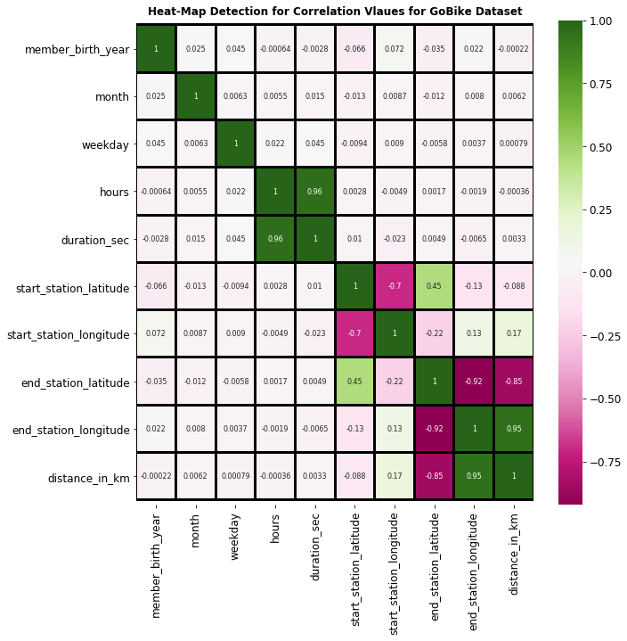

```python
#lets see the correlation of the data
#Reference: https://www.python-graph-gallery.com/heatmap/

plt.figure(figsize=(10, 10))
plt.rcParams.update({'font.size': 8})
plt.rcParams['xtick.labelsize']=12
plt.rcParams['ytick.labelsize']=12

ax1 = sns.heatmap(exp_bike_df.corr(method='pearson'), annot=True, cmap='PiYG', linewidths=2, linecolor='black')
bottom, top = ax1.get_ylim()
ax1.set_ylim(bottom + 0.1, top - 0.1)

ax1.set_title('Heat-Map Detection for Correlation Vlaues for GoBike Dataset',fontweight='bold',size=12)
```

> The strong correlation is shown in the Lat,Lon, and KM (whether it is +ve or -ve correlation)

> also, the strong correlation for the hours and second-time dataset.

> > PS: the colors of heatmap correlation were picked carefully to be a vision for Colorblindness ( the black lines and values for more helpful vision)

```
Male      614139
Female    198757
Other      16381
Name: member_gender, dtype: int64
```

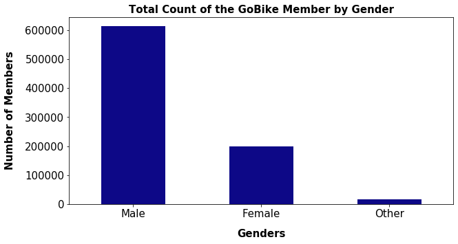

```python
#then plot the Member Gender

bar_gender_df = exp_bike_df['member_gender'].value_counts()

plt.figure(figsize=(10, 5))
plt.rcParams['xtick.labelsize']=15
plt.rcParams['ytick.labelsize']=15

bar_gender_df.plot(kind='bar', rot=0, colormap='plasma')


plt.xlabel('Genders', labelpad=14, fontweight='bold', fontsize=15)
plt.ylabel('Number of Members', labelpad=14, fontweight='bold', fontsize=15)
plt.title("Total Count of the GoBike Member by Gender",fontweight='bold', fontsize=15)

print(bar_gender_df)
```

> Clearly, during the 4-months of 2019, the Males were using the GoBike more that the Females and Others

```
No     752899
Yes     76378
Name: bike_share_for_all_trip, dtype: int64
```

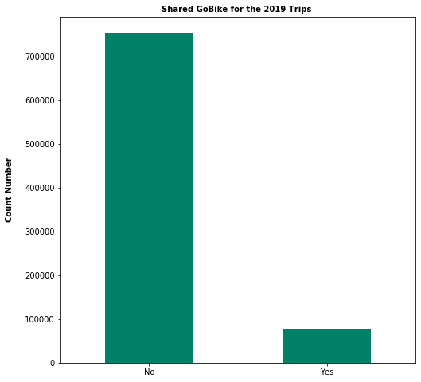

```python
#checking the Sharing bikes
bar_share_df = exp_bike_df['bike_share_for_all_trip'].value_counts()

plt.figure(figsize=(8, 8))
plt.rcParams['xtick.labelsize']=10
plt.rcParams['ytick.labelsize']=10

bar_share_df.plot(kind='bar', rot=0, colormap='summer')



plt.ylabel('Count Number', labelpad=14, fontweight='bold', fontsize=10)
plt.title("Shared GoBike for the 2019 Trips ",fontweight='bold', fontsize=10)

print(bar_share_df)
```

> very few bikes were shared but most of them were not shared

```
Subscriber    734689
Customer       94588
Name: user_type, dtype: int64
```

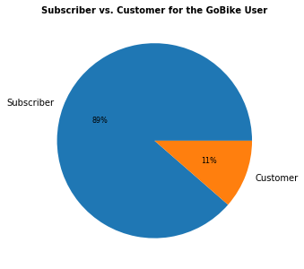

```python
#Subscriber vs Customer
#reference: https://matplotlib.org/stable/api/_as_gen/matplotlib.pyplot.pie.html

pie_type_df = exp_bike_df['user_type'].value_counts()

plt.figure(figsize=(10, 5))
plt.rcParams['xtick.labelsize']=10
plt.rcParams['ytick.labelsize']=10

plt.pie(pie_type_df, labels = pie_type_df.index, autopct='%1.0f%%')
plt.title("Subscriber vs. Customer for the GoBike User",fontweight='bold', fontsize=10);

print(pie_type_df)
```

> clearly, during the 4 months of 2019, 89% of the members were subscribers more than just customers

While checking some details for the DF before continue plotting...

```python
exp_bike_df.describe()
```

|  | member_birth_year | month | weekday | hours | duration_sec | start_station_latitude | start_station_longitude | end_station_latitude | end_station_longitude | distance_in_km |
| --- | --- | --- | --- | --- | --- | --- | --- | --- | --- | --- |
| count | 829277.000000 | 829277.000000 | 829277.000000 | 829277.000000 | 829277.000000 | 829277.000000 | 829277.000000 | 829277.000000 | 829277.000000 | 829277.000000 |
| mean | 1984.728918 | 2.624555 | 2.627822 | 0.025537 | 746.877329 | 37.771338 | -122.353876 | 37.770713 | -122.350970 | 2.012300 |
| std | 10.062619 | 1.105997 | 1.834137 | 0.450653 | 1742.484451 | 0.106908 | 0.177551 | 0.201643 | 0.581650 | 61.294716 |
| min | 1878.000000 | 1.000000 | 0.000000 | 0.000000 | 61.000000 | 0.000000 | -122.453704 | 0.000000 | -122.453704 | 0.000000 |
| 25% | 1980.000000 | 2.000000 | 1.000000 | 0.000000 | 334.000000 | 37.770407 | -122.413004 | 37.770407 | -122.411738 | 0.923270 |
| 50% | 1987.000000 | 3.000000 | 3.000000 | 0.000000 | 531.000000 | 37.780955 | -122.398436 | 37.781010 | -122.398279 | 1.460880 |
| 75% | 1992.000000 | 4.000000 | 4.000000 | 0.000000 | 829.000000 | 37.797320 | -122.289415 | 37.797320 | -122.291209 | 2.277225 |
| max | 2001.000000 | 4.000000 | 6.000000 | 23.000000 | 86114.000000 | 37.880222 | 0.000000 | 37.880222 | 0.000000 | 12808.508332 |

... Found that the minimum of the age are unreasonable, as it start from 1878 which say that 142 yr old are riding bikes

So, thats mean there are outliners for the Age column and will use boxplot to check it.

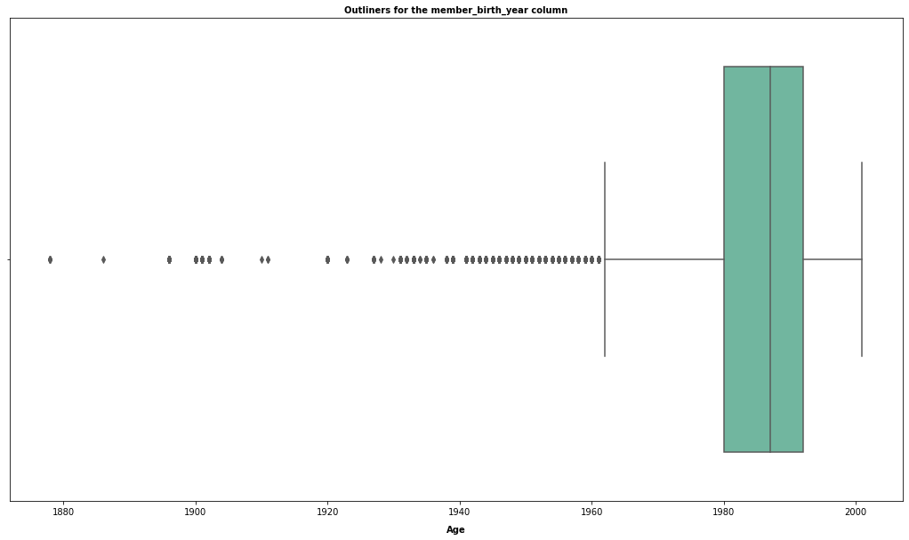

```python
plt.figure(figsize=(18,10))
sns.boxplot(x='member_birth_year', data=exp_bike_df, palette='BuGn')
plt.title("Outliners for the member_birth_year column", fontweight='bold', fontsize=10)
plt.xlabel("Age", fontsize=10, fontweight='bold', labelpad=10);
```

> Above 1960 (which mean above 60 year old) will be dropped

```python
#Reference: https://www.geeksforgeeks.org/drop-rows-from-the-dataframe-based-on-certain-condition-applied-on-a-column/

exp_bike_df.drop(exp_bike_df[exp_bike_df['member_birth_year'] < 1960].index, inplace = True)
```

```python
exp_bike_df.describe()
```

|  | member_birth_year | month | weekday | hours | duration_sec | start_station_latitude | start_station_longitude | end_station_latitude | end_station_longitude | distance_in_km |
| --- | --- | --- | --- | --- | --- | --- | --- | --- | --- | --- |
| count | 764874.000000 | 764874.000000 | 764874.000000 | 764874.000000 | 764874.000000 | 764874.000000 | 764874.000000 | 764874.000000 | 764874.000000 | 764874.000000 |
| mean | 1985.460318 | 2.629546 | 2.627931 | 0.025531 | 745.304912 | 37.771391 | -122.353959 | 37.770750 | -122.351001 | 2.023214 |
| std | 8.831656 | 1.104956 | 1.834248 | 0.450886 | 1742.745845 | 0.107504 | 0.181701 | 0.203431 | 0.588283 | 62.120938 |
| min | 1960.000000 | 1.000000 | 0.000000 | 0.000000 | 61.000000 | 0.000000 | -122.453704 | 0.000000 | -122.453704 | 0.000000 |
| 25% | 1981.000000 | 2.000000 | 1.000000 | 0.000000 | 333.000000 | 37.770407 | -122.413004 | 37.770407 | -122.411738 | 0.926080 |
| 50% | 1987.000000 | 3.000000 | 3.000000 | 0.000000 | 531.000000 | 37.780955 | -122.398436 | 37.781010 | -122.398279 | 1.461522 |
| 75% | 1992.000000 | 4.000000 | 4.000000 | 0.000000 | 827.000000 | 37.797280 | -122.289415 | 37.797320 | -122.291209 | 2.281018 |
| max | 2001.000000 | 4.000000 | 6.000000 | 23.000000 | 86114.000000 | 37.880222 | 0.000000 | 37.880222 | 0.000000 | 12808.508332 |

Now we plot with Barh-plot

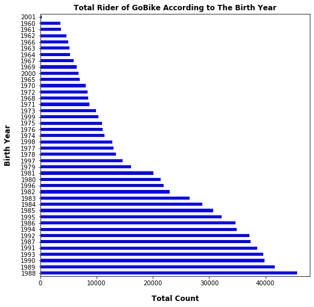

```python
#Age of the Members
#Reference: https://pandas.pydata.org/docs/reference/api/pandas.DataFrame.plot.barh.html

brah_birth_df = exp_bike_df['member_birth_year'].value_counts()

plt.figure(figsize=(8, 8))
plt.rcParams['xtick.labelsize']=10
plt.rcParams['ytick.labelsize']=10

brah_birth_df.plot.barh(stacked=False, color='Blue')


plt.xlabel('Total Count', labelpad=14, fontweight='bold', fontsize=12)
plt.ylabel('Birth Year', labelpad=14, fontweight='bold', fontsize=12)
plt.title("Total Rider of GoBike According to The Birth Year",fontweight='bold', fontsize=12)
```

> It is clearly show that people who born in 1988 ( which there age are 32 yrs old) are most people of rider the bike

Finally, detecting the loaction of the start/end places by using Longitude and Latitude

Reference: https://makersportal.com/blog/2020/4/24/geographic-visualizations-in-python-with-cartopy?fbclid=IwAR33n2FPKiw_t38Yh0_9KgudJr7d8YOjMNnvwVcj7LIS9htyI4se6LW3Sbs

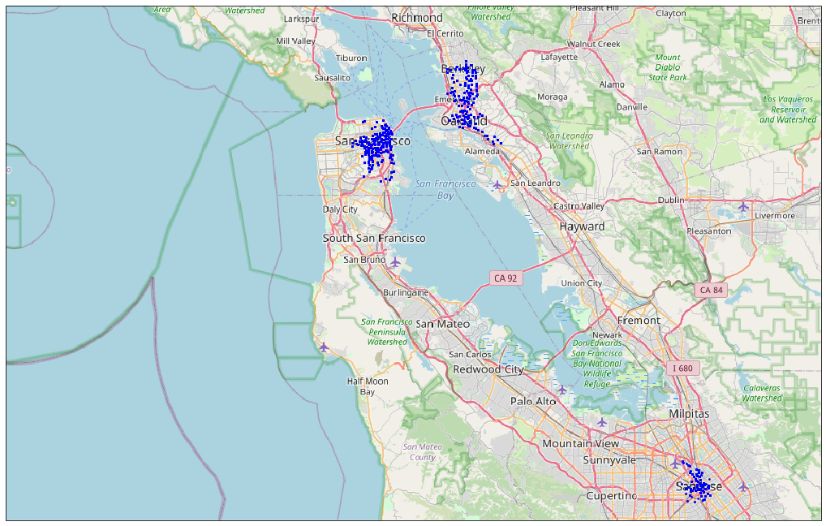

```python
#start to plotting the start points

cen_lan_s = py.mean(exp_bike_df["start_station_latitude"].values)
cen_lon_s = py.mean(exp_bike_df["start_station_longitude"].values)

cimgt.OSM.get_image = image_spoof
osm_img = cimgt.OSM()

fig = plt.figure(figsize = (18,12))
ax1 = plt.axes(projection = osm_img.crs)
zoom = 0.33
shift = 0.15
extent = [cen_lon_s-(zoom*2.0), cen_lon_s+(zoom*2.0), cen_lan_s-zoom-shift, cen_lan_s+zoom-shift]

ax1.set_extent(extent)
scale1 = np.ceil(-np.sqrt(2)*np.log(np.divide(zoom,350.0)))
scale1 = (scale1<20) and scale1 or 19
ax1.add_image(osm_img, int(scale1))

plt.scatter(x=exp_bike_df["start_station_longitude"].values, y=exp_bike_df["start_station_latitude"].values,
            color="blue",
            s=1,
            alpha=0.5,
            transform=crs.PlateCarree())

plt.show()
```

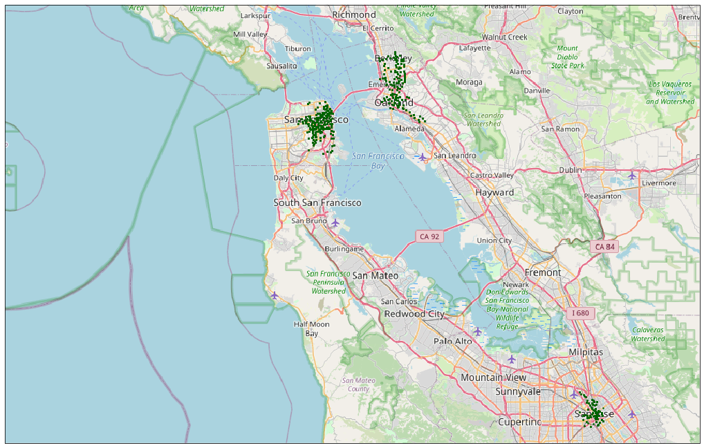

```python
#start to plotting the end points

cen_lan_e = py.mean(exp_bike_df["end_station_latitude"].values)
cen_lon_e = py.mean(exp_bike_df["end_station_longitude"].values)

cimgt.OSM.get_image = image_spoof
osm_img = cimgt.OSM()

fig = plt.figure(figsize=(18,12))
ax1 = plt.axes(projection=osm_img.crs)
zoom = 0.33
shift=0.15

extent = [cen_lon_e-(zoom*2.0),cen_lon_e+(zoom*2.0),cen_lan_e-zoom-shift,cen_lan_e+zoom-shift]
ax1.set_extent(extent) # set extents
scale2 = np.ceil(-np.sqrt(2)*np.log(np.divide(zoom,350.0)))
scale2 = (scale2<20) and scale2 or 19
ax1.add_image(osm_img, int(scale2))

plt.scatter(x=exp_bike_df["end_station_longitude"].values, y=exp_bike_df["end_station_latitude"].values,
            color="darkgreen",
            s=1,
            alpha=0.5,
            transform=crs.PlateCarree())
plt.show()
```

> During 4-months in 2019 the GoBike were used in three different locations:

```
             1- San Francisco Region
             2- between Oakland & Berkeley
             3- San Jose
```

## Univariate Exploration Conclusion

> The single plots shown that most of who used the GoBike are already members and the males are the most highest ones who used the bikes while people with 32 yers old age are the common ones who rent the bike

## Bivariate Exploration

> Lets do pair plotting for some data regards to :

```
1- Sharing Bikes
```

Comparing between the shared_trips and the other columns with the highest values located in (NO) I think it will be unreasonable. So, I will take samples according to the lowest data on the Yes side, to plot the difference in the distance that the shared bike and not-shared one have took.

```python
#separate them into two DFs

yes_share_df = exp_bike_df[exp_bike_df['bike_share_for_all_trip'] == 'Yes']
no_share_df = exp_bike_df[exp_bike_df['bike_share_for_all_trip'] == 'No']
```

```python
#print shape to see the minimum rows
yes_share_df.shape
```

```
(69298, 13)
```

```python
#take 69k random samples for each dfs
yes_share_df = yes_share_df.sample(n=69000, replace = False, random_state=1)
no_share_df = no_share_df.sample(n=69000, replace = False, random_state=1)
```

```python
print(yes_share_df.shape)
print(no_share_df.shape)
```

```
(69000, 13)
(69000, 13)
```

```python
share_trip_df = pd.concat([yes_share_df, no_share_df], sort=False)
```

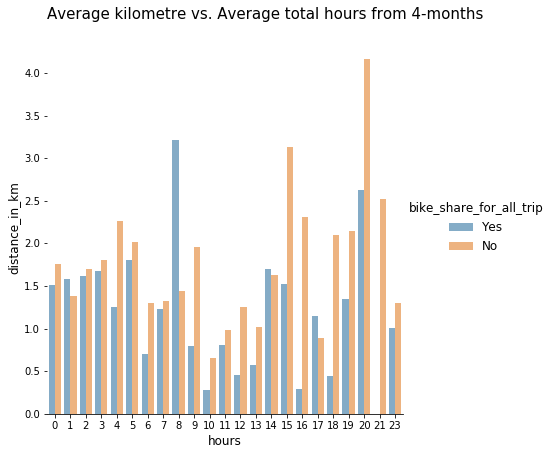

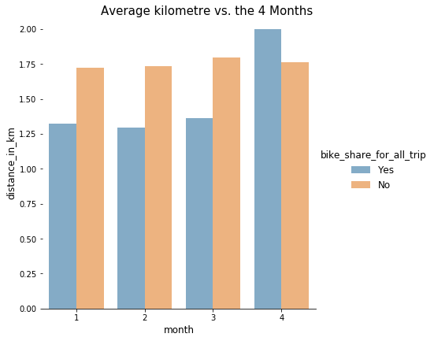

```python
#The two plots will be in vertical plotting visualization
#1st hours with km

plt.rcParams['font.size']=12
plt.rcParams['xtick.labelsize']=10
plt.rcParams['ytick.labelsize']=10

km_hr = sns.catplot(
    data=share_trip_df, kind="bar",
    x="hours", y="distance_in_km", hue="bike_share_for_all_trip",
      alpha=.6, height=6, ci=None)
km_hr.despine(left=True)
km_hr.fig.suptitle('Average kilometre vs. Average total hours from 4-months' , fontsize=15, y=1.05)
plt.show()

#2nd month with km

plt.rcParams['font.size']=12
plt.rcParams['xtick.labelsize']=10
plt.rcParams['ytick.labelsize']=10

km_m = sns.catplot(
    data=share_trip_df, kind="bar",
    x="month", y="distance_in_km", hue="bike_share_for_all_trip",
      alpha=.6, height=6, ci=None)
km_m.despine(left=True)
km_m.fig.suptitle('Average kilometre vs. the 4 Months' , fontsize=15, y=1)
plt.show()
```

> The shared vs. non-shared bike have been compared under total hours from 4 months ( which mean it took the average for hours starting from 00:00 to 23:00) and average distance in Kilometer

Now will do same random sample steps for Subscriber and Customer (will take 87k sample)

```python
sub_df = exp_bike_df[exp_bike_df['user_type'] == 'Subscriber']
cus_df = exp_bike_df[exp_bike_df['user_type'] == 'Customer']

sub_df = sub_df.sample(n=87000, replace = False, random_state=1)
cus_df = cus_df.sample(n=87000, replace = False, random_state=1)

sub_cus_df = pd.concat([sub_df, cus_df], sort=False)
```

```python
sub_cus_df.shape
```

```
(174000, 13)
```

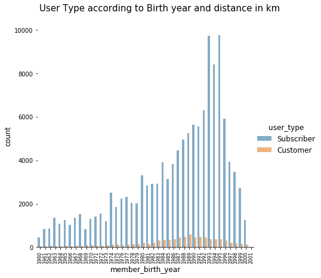

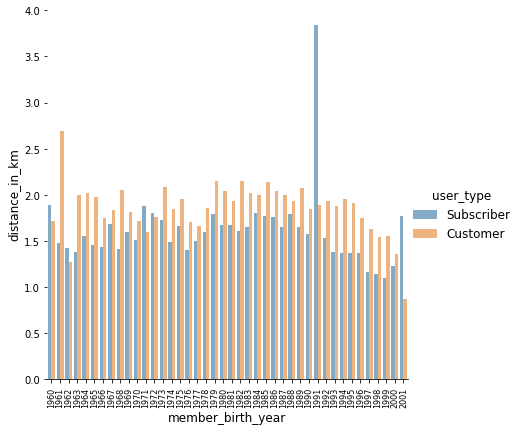

```python
#count birht year members for Subscriber vs Customer

plt.rcParams['font.size']=12
plt.rcParams['xtick.labelsize']=8
plt.rcParams['ytick.labelsize']=10

birth_count = sns.catplot(
    data=share_trip_df, kind="count",
    x="member_birth_year", hue="user_type",
      alpha=.6, height=6, ci=None)
birth_count.set_xticklabels(rotation=90)
birth_count.despine(left=True)
birth_count.fig.suptitle('User Type according to Birth year and distance in km' , fontsize=15, y=1.05)
plt.show()

#distance that have been taken for each of birht year members for Subscriber vs Customer

plt.rcParams['font.size']=12
plt.rcParams['xtick.labelsize']=8
plt.rcParams['ytick.labelsize']=10

birth_km = sns.catplot(
    data=share_trip_df, kind="bar",
    x="member_birth_year", y='distance_in_km', hue="user_type",
      alpha=.6, height=6, ci=None)
birth_km.set_xticklabels(rotation=90)
birth_km.despine(left=True)
plt.show()
```

> the GoBike rider are are subscribers and so few were only costumbers espically from age 38 to 24 yrs old (1982 to 1996).

> yet, most of the subscriber are taking smaller km distance than the customers one except very few of them who are subscriber and using the bike alot with lond km distance ride (like who born in 2001, 1991, 1971, and 1960)

## Bivariate Exploration Conclusion

> With taking random samples for each of shared bikes and user types according to the minimum counts, it gave clear view for the usage of the members to the bikes.

> for the age members most of them were doing the Subscribtion selection instead of bing just costumers.

## Multivariate Exploration

> In this section will use the Gender because it categorized to (Female, Male, and Other).

It needs to be clear that it would not be unreasonable to do plotting to compare about each gender for the distance they make or how many hours they rent the pick and the highest one is the males

So, first I will take samples for each type according to the minimum data...

```python
exp_bike_df['member_gender'].value_counts()
```

```
Male      564619
Female    185072
Other      15183
Name: member_gender, dtype: int64
```

```python
f_df = exp_bike_df[exp_bike_df['member_gender'] == 'Female']
m_df = exp_bike_df[exp_bike_df['member_gender'] == 'Male']
o_df = exp_bike_df[exp_bike_df['member_gender'] == 'Other']

f_df = f_df.sample(n=15000, replace = False, random_state=1)
m_df = m_df.sample(n=15000, replace = False, random_state=1)
o_df = o_df.sample(n=15000, replace = False, random_state=1)

gender_df = pd.concat([f_df, m_df, o_df], sort=False)
```

```python
gender_df.nunique()
```

```
user_type                      2
bike_share_for_all_trip        2
member_birth_year             42
member_gender                  3
month                          4
weekday                        7
hours                         23
duration_sec                3335
start_station_latitude       351
start_station_longitude      351
end_station_latitude         351
end_station_longitude        351
distance_in_km             10268
dtype: int64
```

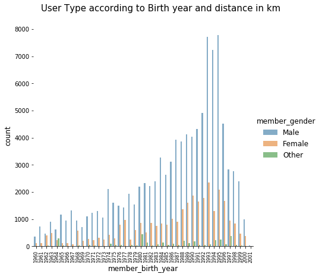

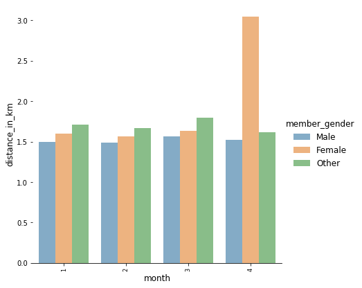

```python
#Count the member birth year according to each gender
plt.rcParams['font.size']=12
plt.rcParams['xtick.labelsize']=8
plt.rcParams['ytick.labelsize']=10

birth_count = sns.catplot(
    data=share_trip_df, kind="count",
    x="member_birth_year", hue="member_gender",
      alpha=.6, height=6, ci=None)
birth_count.set_xticklabels(rotation=90)
birth_count.despine(left=True)
birth_count.fig.suptitle('User Type according to Birth year and distance in km' , fontsize=15, y=1.05)
plt.show()

#average distance for each gender in monthly visualization
plt.rcParams['font.size']=12
plt.rcParams['xtick.labelsize']=8
plt.rcParams['ytick.labelsize']=10

birth_km = sns.catplot(
    data=share_trip_df, kind="bar",
    x="month", y="distance_in_km", hue="member_gender",
      alpha=.6, height=6, ci=None)
birth_km.set_xticklabels(rotation=90)
birth_km.despine(left=True)
plt.show()
```

> However, significantly the Female and Others were the ones who took the longest distance in km compared to Males.

# Conclusion